# examples_0407

Let function $f$ represent a cubic polynomial function with **integer** coefficients.

$$f(x)~=~ax^3+bx^2+cx+d$$

That function has a real root $x=\frac{-7}{8}$ and a complex root $x=7-2i$.

$$f\left(\frac{-7}{8}\right)~=~0$$
$$f(7-2i)~=~0$$

Assuming $a>0$ and $a$ is the smallest possible integer with those given roots, find all the coefficients.

- $a=$
- $b=$
- $c=$
- $d=$

When a polynomial with real coefficients has complex roots, they always come as [complex-conjugate](https://en.wikipedia.org/wiki/Complex_conjugate) pairs. Thus, we know all three factors.

$$f(x)~=~({8}x+{7})(x-(7-2i))(x-(7+2i))$$

Distribute subtraction across inner parentheses.

$$f(x)~=~({8}x+{7})(x-7+2i)(x-7-2i)$$

Multiply the two complex-root factors using a box.

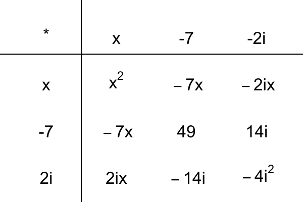

Notice some of those terms cancel.

$$f(x)~=~({8}x+{7})(x^2-14x+49-4i^2)$$

Remember that $i^2=-1$.

$$f(x)~=~({8}x+{7})(x^2-14x+49-4(-1))$$

$$f(x)~=~({8}x+{7})(x^2-14x+49+4)$$

$$f(x)~=~({8}x+{7})(x^2-14x+53)$$

Use another box to expand the product into standard form.

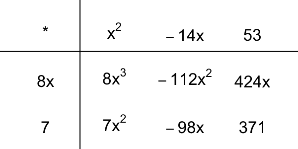

Combine like terms.

$$f(x)~=~{8}x^{3}-{105}x^{2}+{326}x+{371}$$

Let function $f$ represent a cubic polynomial function with **integer** coefficients.

$$f(x)~=~ax^3+bx^2+cx+d$$

That function has a real root $x=\frac{-9}{2}$ and a complex root $x=5+2i$.

$$f\left(\frac{-9}{2}\right)~=~0$$
$$f(5+2i)~=~0$$

Assuming $a>0$ and $a$ is the smallest possible integer with those given roots, find all the coefficients.

- $a=$
- $b=$
- $c=$
- $d=$

When a polynomial with real coefficients has complex roots, they always come as [complex-conjugate](https://en.wikipedia.org/wiki/Complex_conjugate) pairs. Thus, we know all three factors.

$$f(x)~=~({2}x+{9})(x-(5+2i))(x-(5-2i))$$

Distribute subtraction across inner parentheses.

$$f(x)~=~({2}x+{9})(x-5-2i)(x-5+2i)$$

Multiply the two complex-root factors using a box.

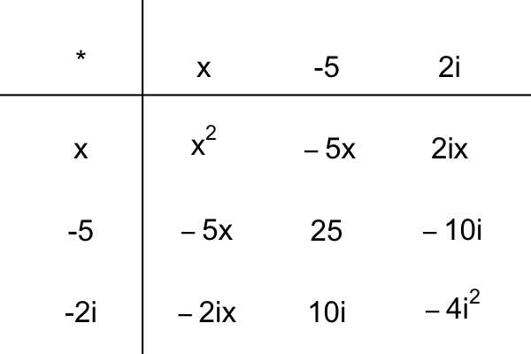

Notice some of those terms cancel.

$$f(x)~=~({2}x+{9})(x^2-10x+25-4i^2)$$

Remember that $i^2=-1$.

$$f(x)~=~({2}x+{9})(x^2-10x+25-4(-1))$$

$$f(x)~=~({2}x+{9})(x^2-10x+25+4)$$

$$f(x)~=~({2}x+{9})(x^2-10x+29)$$

Use another box to expand the product into standard form.

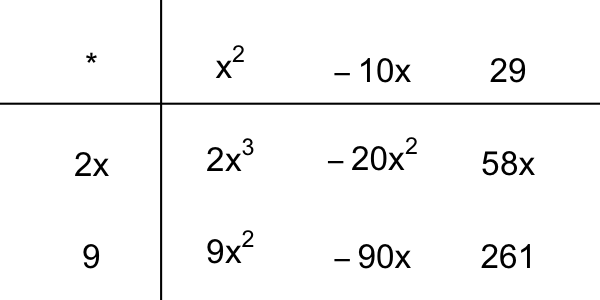

Combine like terms.

$$f(x)~=~{2}x^{3}-{11}x^{2}-{32}x+{261}$$

Let function $f$ represent a cubic polynomial function with **integer** coefficients.

$$f(x)~=~ax^3+bx^2+cx+d$$

That function has a real root $x=\frac{7}{8}$ and a complex root $x=-9-7i$.

$$f\left(\frac{7}{8}\right)~=~0$$
$$f(-9-7i)~=~0$$

Assuming $a>0$ and $a$ is the smallest possible integer with those given roots, find all the coefficients.

- $a=$
- $b=$
- $c=$
- $d=$

When a polynomial with real coefficients has complex roots, they always come as [complex-conjugate](https://en.wikipedia.org/wiki/Complex_conjugate) pairs. Thus, we know all three factors.

$$f(x)~=~({8}x-{7})(x-(-9-7i))(x-(-9+7i))$$

Distribute subtraction across inner parentheses.

$$f(x)~=~({8}x-{7})(x+9+7i)(x+9-7i)$$

Multiply the two complex-root factors using a box.

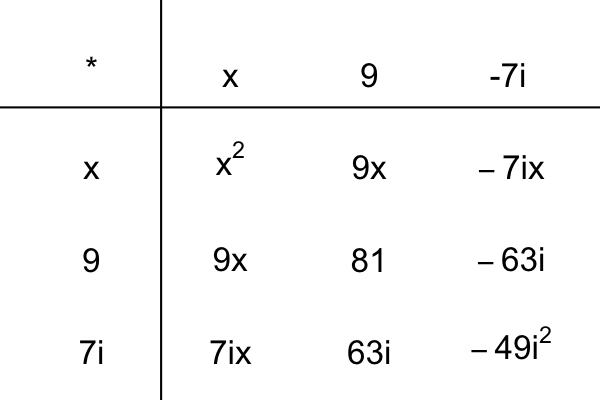

Notice some of those terms cancel.

$$f(x)~=~({8}x-{7})(x^2+18x+81-49i^2)$$

Remember that $i^2=-1$.

$$f(x)~=~({8}x-{7})(x^2+18x+81-49(-1))$$

$$f(x)~=~({8}x-{7})(x^2+18x+81+49)$$

$$f(x)~=~({8}x-{7})(x^2+18x+130)$$

Use another box to expand the product into standard form.

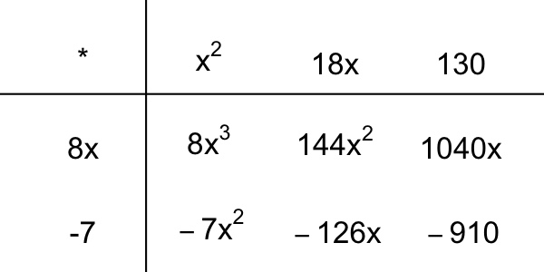

Combine like terms.

$$f(x)~=~{8}x^{3}+{137}x^{2}+{914}x-{910}$$

Let function $f$ represent a cubic polynomial function with **integer** coefficients.

$$f(x)~=~ax^3+bx^2+cx+d$$

That function has a real root $x=\frac{2}{3}$ and a complex root $x=-2+9i$.

$$f\left(\frac{2}{3}\right)~=~0$$
$$f(-2+9i)~=~0$$

Assuming $a>0$ and $a$ is the smallest possible integer with those given roots, find all the coefficients.

- $a=$
- $b=$
- $c=$
- $d=$

When a polynomial with real coefficients has complex roots, they always come as [complex-conjugate](https://en.wikipedia.org/wiki/Complex_conjugate) pairs. Thus, we know all three factors.

$$f(x)~=~({3}x-{2})(x-(-2+9i))(x-(-2-9i))$$

Distribute subtraction across inner parentheses.

$$f(x)~=~({3}x-{2})(x+2-9i)(x+2+9i)$$

Multiply the two complex-root factors using a box.

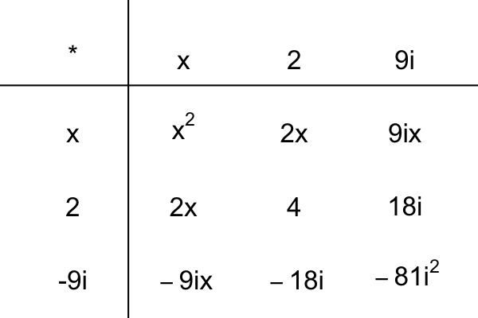

Notice some of those terms cancel.

$$f(x)~=~({3}x-{2})(x^2+4x+4-81i^2)$$

Remember that $i^2=-1$.

$$f(x)~=~({3}x-{2})(x^2+4x+4-81(-1))$$

$$f(x)~=~({3}x-{2})(x^2+4x+4+81)$$

$$f(x)~=~({3}x-{2})(x^2+4x+85)$$

Use another box to expand the product into standard form.

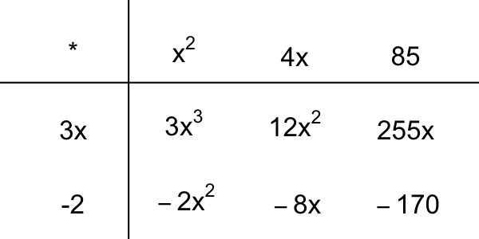

Combine like terms.

$$f(x)~=~{3}x^{3}+{10}x^{2}+{247}x-{170}$$

Let function $f$ represent a cubic polynomial function with **integer** coefficients.

$$f(x)~=~ax^3+bx^2+cx+d$$

That function has a real root $x=\frac{9}{2}$ and a complex root $x=-2+7i$.

$$f\left(\frac{9}{2}\right)~=~0$$
$$f(-2+7i)~=~0$$

Assuming $a>0$ and $a$ is the smallest possible integer with those given roots, find all the coefficients.

- $a=$
- $b=$
- $c=$
- $d=$

When a polynomial with real coefficients has complex roots, they always come as [complex-conjugate](https://en.wikipedia.org/wiki/Complex_conjugate) pairs. Thus, we know all three factors.

$$f(x)~=~({2}x-{9})(x-(-2+7i))(x-(-2-7i))$$

Distribute subtraction across inner parentheses.

$$f(x)~=~({2}x-{9})(x+2-7i)(x+2+7i)$$

Multiply the two complex-root factors using a box.

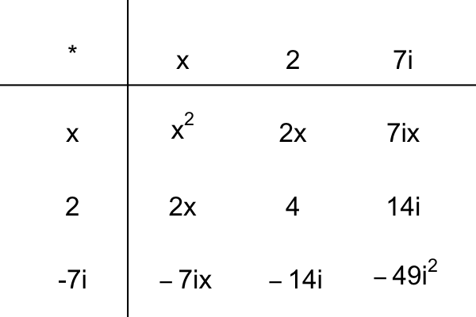

Notice some of those terms cancel.

$$f(x)~=~({2}x-{9})(x^2+4x+4-49i^2)$$

Remember that $i^2=-1$.

$$f(x)~=~({2}x-{9})(x^2+4x+4-49(-1))$$

$$f(x)~=~({2}x-{9})(x^2+4x+4+49)$$

$$f(x)~=~({2}x-{9})(x^2+4x+53)$$

Use another box to expand the product into standard form.

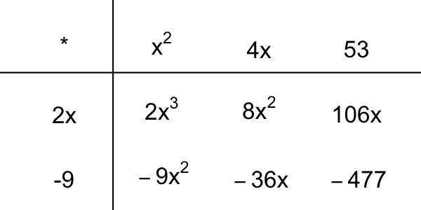

Combine like terms.

$$f(x)~=~{2}x^{3}-x^{2}+{70}x-{477}$$